# Harry Potter Episode 2 - Chocolate Frog - linear regression

## Installing required packages

```r
# to install run the codes below
 #install.packages("jtools")
 #install.packages("tidyverse")
 #install.packages("ggpubr")
 #install.packages("kableExtra")
```

## Loading packages

```r
library("jtools") # for summarising regression models
library("tidyverse") # use ggplot for plotting results
library("ggpubr") # for adding equation and R2 to ggplot-generated plot
library("kableExtra") # for formatting tables
```

## Load dataset

```r
chocolate_frog <- read_csv("chocolate frog dataset.csv")
# show clean table using kableExtra
kbl(chocolate_frog[1:10,], caption = "Chocolate Frog data") %>%
  kable_styling(bootstrap_options = c("striped", "hover"))
```

Chocolate Frog data

| student_id | allowance | chocolate_frog_eaten |
| --- | --- | --- |
| 1 | 3.862647 | 2.314489 |
| 2 | 4.979381 | 3.433490 |
| 3 | 4.923957 | 4.599373 |
| 4 | 3.214372 | 2.791114 |
| 5 | 7.196409 | 5.596398 |
| 6 | 3.729643 | 2.458556 |
| 7 | 4.674517 | 3.192992 |
| 8 | 4.498104 | 1.907137 |
| 9 | 3.121631 | 2.942450 |
| 10 | 4.639914 | 3.737942 |

##### Explanation of dataset

- `allowance` Amount of allowance each student receives per week, converted to Galleons.
- `chocolate_frog_eaten` Amount of chocolate frogs eaten per week.

## Checking that the data meet the assumptions of linear regression

- `Normality` Check whether the dependent or response variable follows a normal distribution.
- `Linearity` Check whether the relationship between the predictor and response variables is linear.
- `Homoscedasticity` Check whether the model fits the homoscedasticity assumption. Homoscedasticity is a situation whereby the variance of the response variable is the same for all the data.
- `Independence of observations` Check whether auto-correlation exists. This does not apply in our case because we only have one independent/predictor variable.

#### Checking whether the dependent/response variable follows a normal distribution using the hist() function

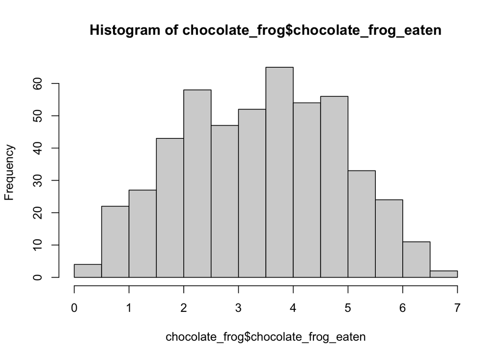

```r
hist(chocolate_frog$chocolate_frog_eaten)
```

The observations more or less follow a bell-shaped curve, thus having a normal distribution.

#### Checking whether the relationship between response and predictor variables is linear using a scatter plot.

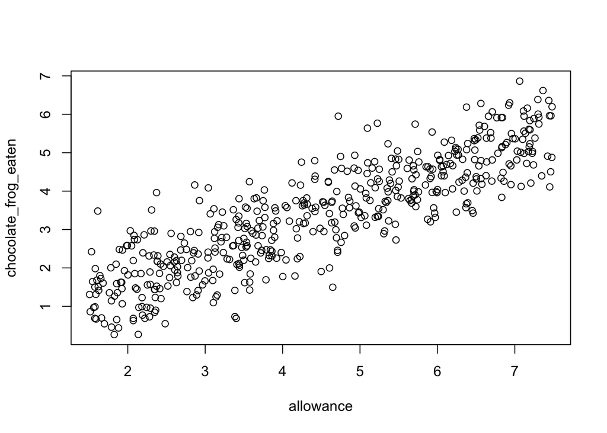

```r
plot(chocolate_frog_eaten ~ allowance, data = chocolate_frog)
```

The relationship appears to be more or less linear and follows a straight line.  
We will test for homoscedasticity after creating the model.

## Fitting the model

```r
model <- lm(chocolate_frog_eaten ~ allowance, data = chocolate_frog)
summary(model)
```

```
##
## Call:
## lm(formula = chocolate_frog_eaten ~ allowance, data = chocolate_frog)
##
## Residuals:
##      Min       1Q   Median       3Q      Max
## -2.02479 -0.48526  0.04078  0.45898  2.37805
##
## Coefficients:
##             Estimate Std. Error t value Pr(>|t|)
## (Intercept)  0.20427    0.08884   2.299   0.0219 *
## allowance    0.71383    0.01854  38.505   <2e-16 ***
## ---
## Signif. codes:  0 '***' 0.001 '**' 0.01 '*' 0.05 '.' 0.1 ' ' 1
##
## Residual standard error: 0.7181 on 496 degrees of freedom
## Multiple R-squared:  0.7493, Adjusted R-squared:  0.7488
## F-statistic:  1483 on 1 and 496 DF,  p-value: < 2.2e-16
```

#### Creating clean summary table

```r
render = 'normal_print'

summ(model)
```

| Observations | 498 |
| --- | --- |
| Dependent variable | chocolate_frog_eaten |
| Type | OLS linear regression |

| F(1,496) | 1482.63 |
| --- | --- |
| R² | 0.75 |
| Adj. R² | 0.75 |

|  | Est. | S.E. | t val. | p |
| --- | --- | --- | --- | --- |
| (Intercept) | 0.20 | 0.09 | 2.30 | 0.02 |
| allowance | 0.71 | 0.02 | 38.50 | 0.00 |

Standard errors: OLS

##### Explanation of results

- `Coefficients` The y-intercept value in this case is 0.20. And the estimated effect of weekly allowance on amount of chocolate frog eaten is 0.71. This means that the average number of chocolate frog eaten increases in 0.71 for every Galleon of allowance a student has.
- `P-value` The p-value is < 2.2e-16, which is almost zero. This means that the model fits the data well.

Overall, this means that there is a significant positive relationship between allowance and the amount of chocolate frogs eaten (p-value < 0.0001). Whereby a 0.71 increase in chocolate frog for every unit increase in Galleon.

## Checking for homoscedasticity

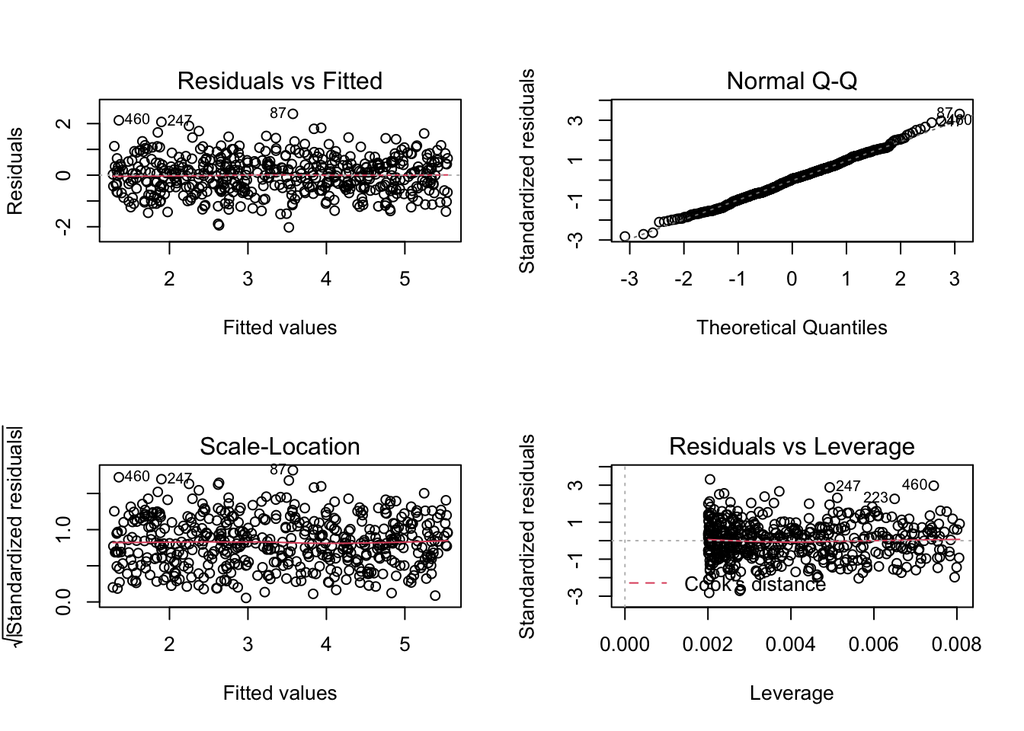

```r
par(mfrow=c(2,2))
plot(model)
```

- `par(mfrow())` This command devides the plots into the number of rows and columns specified. Thus, par(mfrow=c(2,2)) means two rows and two columns.
- `Residuals` are the diferences between the real values and predicted values. Residuals are to be expected because in real life, most cases will not follow a straight line. Referring to the summary above, the median of the residuals is approximately zero (0.04078).

Take a look at the red line in the residuals plot, which represents the mean of the residuals, which is centred around zero.  
This means that there are not outliers that may make a linear regression void.

- `Q-Q plot`Allows one to check for normality by comparing how close two distributions are. In this case, the real residuals from the model form a well-aligned one-to-one line with the theoretical residuals.  
  Based on the above, we can conclude that the model meets the homoscedasticity assumption.

## Visualising results using ggplot2

#### Basic graph

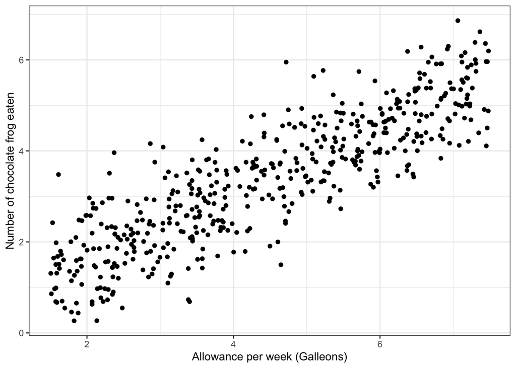

```r
p <-ggplot(chocolate_frog, aes(x=allowance, y=chocolate_frog_eaten))+
                     geom_point() + theme_bw() +
    ylab("Number of chocolate frog eaten") +
    xlab("Allowance per week (Galleons)")

p
```

#### Adding regression line

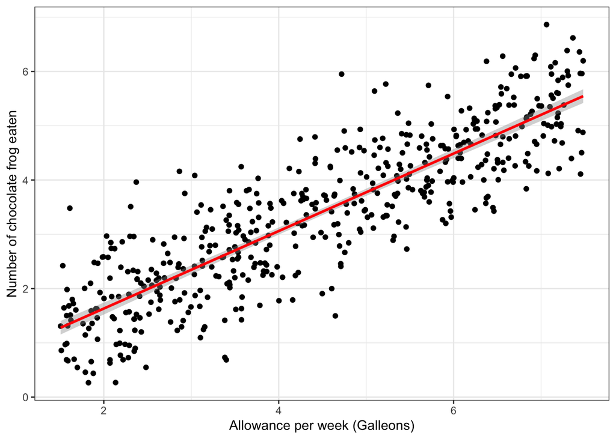

```r
p <-ggplot(chocolate_frog, aes(x=allowance, y=chocolate_frog_eaten))+
                     geom_point() + theme_bw() +
    ylab("Number of chocolate frog eaten") +
    xlab("Allowance per week (Galleons)") +
    geom_smooth(method="lm", col="red")

p
```

#### Adding equation and R2

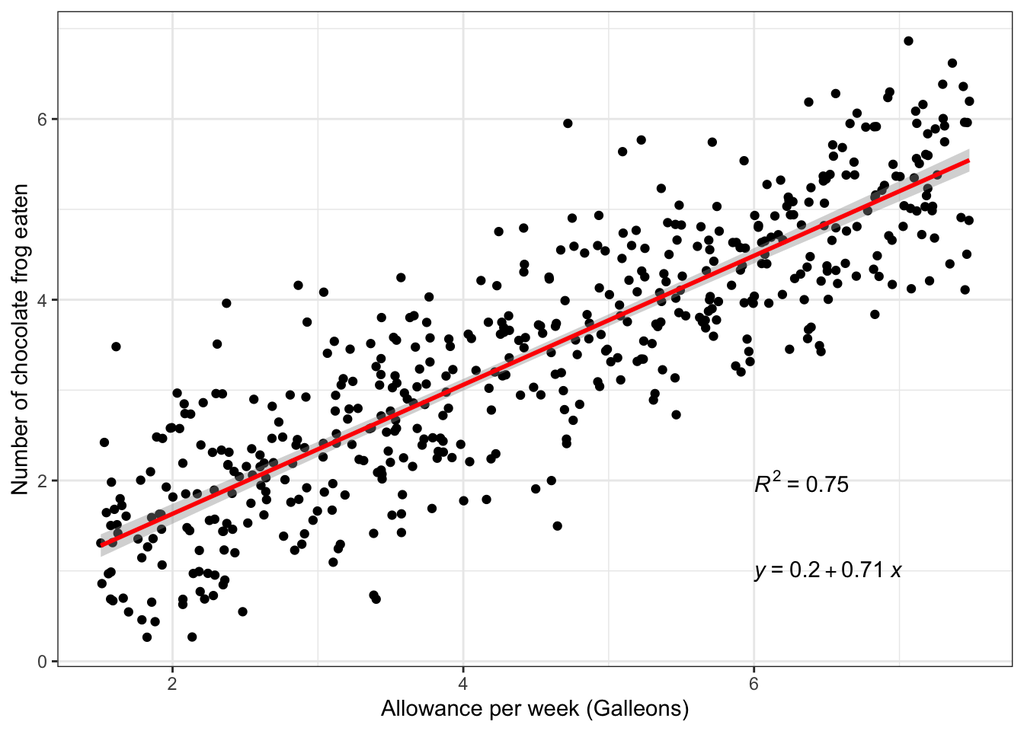

```r
p <-ggplot(chocolate_frog, aes(x=allowance, y=chocolate_frog_eaten))+
                     geom_point() + theme_bw() +
    ylab("Number of chocolate frog eaten") +
    xlab("Allowance per week (Galleons)") +
    geom_smooth(method="lm", col="red") +
    stat_regline_equation(label.x = 6, label.y = 1, aes(label = ..eq.label..)) + # ggpubr package  equation
    stat_regline_equation(label.x = 6, label.y = 2, aes(label = ..rr.label..)) # # ggpubr package r2

p
```

The R2 value or coefficient of determination can be used to test if your model has a good fit. Models that fit the data well have R2 of close to 1.

Models that fit poorly have R2 close to zero.

R2 of 0.75 means that the model explains 75% of the total variability, which is considered good.